# 3. Klauzule abuzywne

### Analiza wielowymiarowych wektorów

Ciężko jest nam wyobrazić sobie i analizować wektory, które mają więcej niż trzy wymiary. Na szczęście są algorytmy, które mogą nam w tym pomóc. PCA i t-SNE pozwalają zredukować ilość wymiarów wektora, starając się jak najbardziej zachować jego odróżnialność od pozostałych wektorów w zbiorze. Dzięki temu możemy zrzutować każde z naszych zdań na płaszczyznę i narysować wykres pokazujący je jako kropki (kolor zależy od tego czy są abuzywne, czy nie).

```python
from sklearn.decomposition import PCA
from sklearn.manifold import TSNE

emb_50 = PCA(n_components=50).fit_transform(np.stack(data['mean_embedd']))
emb_2 = TSNE(n_components = 2, perplexity = 50, init='pca', learning_rate='auto').fit_transform(emb_50)
```

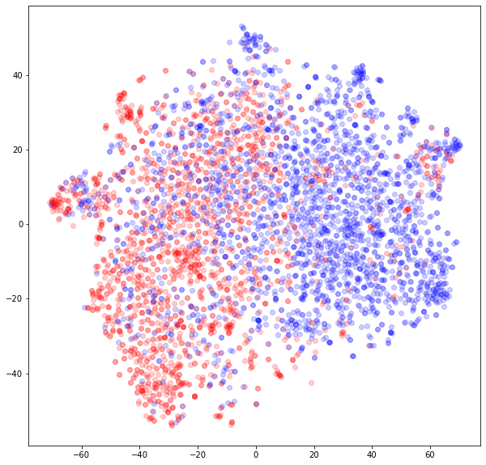

```python
import pylab as plt

plt.figure(figsize=(10,10))
plt.scatter(emb_2[:,0][data['abusive']],emb_2[:,1][data['abusive']],
            color = 'r', alpha = 0.2, label = 'bad')
plt.scatter(emb_2[:,0][~data['abusive']],emb_2[:,1][~data['abusive']],
            color = 'b', alpha = 0.2, label = 'good')
```

Analiza tego wykresu sugeruje, że nasze wektory pozwolą nam, przynajmniej częsciwo, oddzielić bezpieczne zapisy od abuzywnych. Ponieważ PCA i t-SNE są przekształceniami, które tracą część informacji, więc skorzystamy z wektorów pełnej długości (300 elementowych). Do stworzenia klasyfikatora wykorzystamy metodę Random Forrest.

```python
from sklearn.ensemble import RandomForestClassifier

np.random.seed(42)
train_mask = np.random.random(len(data)) > .1

random_forest = RandomForestClassifier(n_estimators = 100, max_depth = None, oob_score=True, max_features = 'sqrt')
random_forest.fit(np.stack(data['mean_embedd'])[train_mask], data['abusive'][train_mask])
```

```
RandomForestClassifier(max_features='sqrt', oob_score=True)
```

```python
random_forest.oob_score_
```

```
0.8268025078369906
```

82% skuteczności, całkiem nieźle! Zerknijmy na wyniki:

```python
data['mean_abusive_prob'] = [i[1] for i in random_forest.predict_proba(np.stack(data['mean_embedd']))]
```

```python
data['mean_abusive_pred'] = data['mean_abusive_prob'] > 0.5
```

```python
data[['text', 'abusive', 'mean_abusive_prob']]
```

|  | text | abusive | mean_abusive_prob |
| --- | --- | --- | --- |
| 0 | Wszelka korespondencja wysyłana przez Pożyczkodawcę na adres zamieszkania podany w umowie oraz na e-mail zostaje uznana za skutecznie doręczoną. Zmiana adresu e-mail oraz adresu zamieszkania musi być … | True | 0.86 |
| 1 | W przypadku opóźnień Pożyczkobiorcy w spłacie pożyczki Pożyczkodawca ma prawo raz dziennie telefonicznie upomnieć Pożyczkobiorcę do spłaty pożyczki. Za każdy telefon do Pożyczkobiorcy Pożyczkodawca na… | True | 0.78 |
| 2 | W przypadku opóźnień Pożyczkobiorcy w spłacie pożyczki Pożyczkodawca ma prawo wysłać jedno wezwanie dziennie do spłaty pożyczki za pomocą poczty tradycyjnej oraz mailowej na adresy podane w umowie. Za… | True | 0.88 |
| 3 | Pożyczkobiorca zleca firmie Narodowy Fundusz Pożyczkowy Sp. z o.o. poręczenie swojej pożyczki i zobowiązuje się zapłacić na rzecz Pożyczkodawcy kwotę 1000 zł (słownie: jeden tysiąc złotych) miesięczni… | True | 0.77 |
| 4 | Od niespłaconej w terminie raty Pożyczkobiorca zapłaci Pożyczkodawcy opłaty karne w wysokości 200 złotych w stosunku dziennym | True | 0.82 |
| ... | ... | ... | ... |
| 4279 | CESJA PRAW Z UBEZPIECZENIA NIERUCHOMOŚCI | False | 0.16 |
| 4280 | Przyznanie i prolongowanie Kredytów na zakup pojazdów Zgodnie z warunkami wynikającymi z umowy | False | 0.13 |
| 4281 | Dotyczy to również niniejszych Warunków Imprez Turystycznych, stanowiących integralną część umowy o udział w imprezie turystycznej. | False | 0.12 |
| 4282 | Suma ubezpieczenia w kolejnych ubezpieczeniach powinna być równa wartości nieruchomości na moment przedłużenia ubezpieczenia, z zastrzeżeniem ust. | False | 0.26 |
| 4283 | Saldo Konta Oszczędnościowego Oprocentowanie promocyjne Do 200 000 PLN dla Nowych środków 3,00%* Pozostałe środki zgodnie z pkt. | False | 0.11 |

4284 rows × 3 columns

Wygląda na to, że nasz model przypisuje wyoskie prawdopodobnieństwa klauzulom abuzywnych, a niskie – bezpiecznym. Zobaczmy jeszcze kilka pomyłek:

```python
data[['text', 'abusive', 'mean_abusive_pred']]
```

|  | text | abusive | mean_abusive_pred |
| --- | --- | --- | --- |
| 0 | Wszelka korespondencja wysyłana przez Pożyczkodawcę na adres zamieszkania podany w umowie oraz na e-mail zostaje uznana za skutecznie doręczoną. Zmiana adresu e-mail oraz adresu zamieszkania musi być … | True | True |
| 1 | W przypadku opóźnień Pożyczkobiorcy w spłacie pożyczki Pożyczkodawca ma prawo raz dziennie telefonicznie upomnieć Pożyczkobiorcę do spłaty pożyczki. Za każdy telefon do Pożyczkobiorcy Pożyczkodawca na… | True | True |
| 2 | W przypadku opóźnień Pożyczkobiorcy w spłacie pożyczki Pożyczkodawca ma prawo wysłać jedno wezwanie dziennie do spłaty pożyczki za pomocą poczty tradycyjnej oraz mailowej na adresy podane w umowie. Za… | True | True |
| 3 | Pożyczkobiorca zleca firmie Narodowy Fundusz Pożyczkowy Sp. z o.o. poręczenie swojej pożyczki i zobowiązuje się zapłacić na rzecz Pożyczkodawcy kwotę 1000 zł (słownie: jeden tysiąc złotych) miesięczni… | True | True |
| 4 | Od niespłaconej w terminie raty Pożyczkobiorca zapłaci Pożyczkodawcy opłaty karne w wysokości 200 złotych w stosunku dziennym | True | True |
| ... | ... | ... | ... |
| 4279 | CESJA PRAW Z UBEZPIECZENIA NIERUCHOMOŚCI | False | False |
| 4280 | Przyznanie i prolongowanie Kredytów na zakup pojazdów Zgodnie z warunkami wynikającymi z umowy | False | False |
| 4281 | Dotyczy to również niniejszych Warunków Imprez Turystycznych, stanowiących integralną część umowy o udział w imprezie turystycznej. | False | False |
| 4282 | Suma ubezpieczenia w kolejnych ubezpieczeniach powinna być równa wartości nieruchomości na moment przedłużenia ubezpieczenia, z zastrzeżeniem ust. | False | False |
| 4283 | Saldo Konta Oszczędnościowego Oprocentowanie promocyjne Do 200 000 PLN dla Nowych środków 3,00%* Pozostałe środki zgodnie z pkt. | False | False |

4284 rows × 3 columns

```python
val_data = data[~train_mask]
```

```python
val_data[['text', 'abusive', 'mean_abusive_prob']][val_data['mean_abusive_pred'] != val_data['abusive']].sort_values('mean_abusive_prob')
```

|  | text | abusive | mean_abusive_prob |
| --- | --- | --- | --- |
| 369 | Zwrot pieniędzy następuje po odesłaniu przez Klienta podpisanej kopii faktury/noty korygującej na adres sprzedawcy: STIMO, ul. Sikorskiego 11a; 38-400 Krosno. | True | 0.04 |
| 1319 | Strony mają obowiązek rozwiązywać wszelkie spory w sposób polubowny. Procedura oficjalnej skargi: a) Rodzic niezwłocznie zawiadamia Sekretariat pisemnie lub e-mail’em o zaistniałym problemie; Przedszk… | True | 0.12 |
| 486 | Bank może w trakcie obowiązywania Umowy: 1) zwiększyć wysokość przyznanego Limitu, o ile zdolność kredytowa Posiadacza/y rachunku będzie pozwalała na spłatę zwiększonej wysokości Limitu, a Posiadacz/e… | True | 0.13 |
| 1116 | W przypadku braku spłaty należności Pożyczkodawcy z tytułu udzielonej Pożyczkobiorcy pożyczki, w terminie określonym w niniejszej Umowie Pożyczki, Pożyczkodawca ma prawo do wystąpienia na drogę windyk… | True | 0.14 |
| 83 | Zgodnie z Ustawą z dn. 2.03.2000 r. (Dz.U. z 2000 r. Nr 22, poz. 271 z późniejszymi zmianami) O ochronie praw konsumentów - Klient, który zakupił towar poza lokalem oferującego go przedsiębiorstwa ma … | True | 0.15 |
| ... | ... | ... | ... |
| 2448 | •Status sponsora Imprezy przyznaje wyłącznie Organizator. Organizator nie ponosi odpowiedzialności za skutki działania Siły Wyższej. | False | 0.79 |
| 1997 | Kupujący może złożyć reklamacje wraz z reklamowanym Towarem oraz fakturą dokumentującą dokonanie zakupu na adres: Fabryka Graczy Sp. z o.o. ul. Konstantynowska 34, 94-303. W celu usprawnienia procesu … | False | 0.80 |
| 3743 | a)kosztów naprawy, jeśli uszkodzenia dają się usunąć, b)kary umownej za wymianę Sprzętu zgodnie z Cennikiem, jeśli Sprzęt został utracony łub jeżeli uszkodzenia nie dają się usunąć. | False | 0.85 |
| 2212 | Sądem właściwym dla rozpoznawania sporów wynikających z umowy jest sąd właściwy dla miejsca zamieszkania pozwanego | False | 0.89 |
| 2023 | Operatorowi usług przysługuje prawo do rozwiązania umowy tylko z ważnych przyczyn, przede wszystkim kiedy b) zaistnieją okoliczności powodujące, że dalsze trwanie umowy narażałoby operatora na szkody … | False | 0.92 |

91 rows × 3 columns

```python
len(val_data)
```

```
456
```

```python
1 - 91 / len(val_data)
```

```
0.8004385964912281
```

91 błędów na 456 klauzul. Dokładność na poziomie 80%. Trochę za mało, żeby zastąpić prawników i sędziów komputerami, ale w kolejnym kursie sprawdzimy jak możemy tę dokładność mocno poprawić.